# K_means examples (UKDS workshop)

Modified by…

Ben Anderson

Last run: 2022-10-24 16:58:52

## Code

- Original code & contributors: https://github.com/UKDataServiceOpen/ML_Workshop
- This fork: https://github.com/dataknut/ML_Workshop

## Install Packages

```r
#install.packages("factoextra")
#install.packages("stats")
#install.packages("janitor")
#install.packages("ClusterR")
#install.packages("cluster")
#install.packages("tidyverse")

# Loading package
# library(ClusterR)
# library(cluster)
# library(factoextra)
# library(stats)
# library(janitor)
# library(dplyr)
# library(tidyverse)
# library(cluster)

library(dkUtils) # find it at https://github.com/dataknut/dkUtils

myLibs <- c("factoextra", "stats", "janitor", "ClusterR", "cluster", "tidyverse",
            "ggplot2")
dkUtils::loadLibraries(myLibs) # magic
```

```
## factoextra      stats    janitor   ClusterR    cluster  tidyverse    ggplot2
##       TRUE       TRUE       TRUE       TRUE       TRUE       TRUE       TRUE
```

# Introduction

**Clustering** is a technique in machine learning that attempts to find clusters of observations within a dataset.

The goal is to find clusters such that the observations within each cluster are quite similar to each other, while observations in different clusters are quite different from each other.

Clustering is a form of unsupervised learning because we’re simply attempting to find structure within a dataset rather than predicting the value of some response variable.

*K - Means* clustering is a technique in which we place each observation in a dataset into one of K clusters.

> k-means requires numeric data as it wants to compute centroids? (check)

The end goal is to have K clusters in which the observations within each cluster are quite similar to each other while the observations in different clusters are quite different from each other.

How it works:

1. Choose a value for K
2. Randomly assign each observation to an initial cluster, from 1 to K
3. Compute the cluster centroid (vector of the P feature means for the observation in the Kth cluster)

# Case Studies

## 1 - USA Arrests DataSet (R DataSet)

> XX why nstart = 25? X why centres = 2? Do we suspect 2 clusters… or…what?

```r
#read in data
df <- USArrests %>% na.omit(df)

## Scaling and standardising
head(df)
```

```
##            Murder Assault UrbanPop Rape
## Alabama      13.2     236       58 21.2
## Alaska       10.0     263       48 44.5
## Arizona       8.1     294       80 31.0
## Arkansas      8.8     190       50 19.5
## California    9.0     276       91 40.6
## Colorado      7.9     204       78 38.7
```

```r
df <- scale(df) # centres & standardises data etc - requires numeric-only columns, states are row names
head(df)
```

```
##                Murder   Assault   UrbanPop         Rape
## Alabama    1.24256408 0.7828393 -0.5209066 -0.003416473
## Alaska     0.50786248 1.1068225 -1.2117642  2.484202941
## Arizona    0.07163341 1.4788032  0.9989801  1.042878388
## Arkansas   0.23234938 0.2308680 -1.0735927 -0.184916602
## California 0.27826823 1.2628144  1.7589234  2.067820292
## Colorado   0.02571456 0.3988593  0.8608085  1.864967207
```

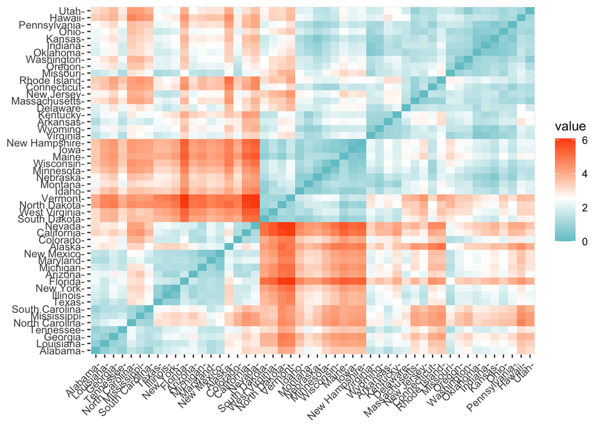

```r
#compute distance matrix
distance <- factoextra::get_dist(df)
factoextra::fviz_dist(distance, gradient = list(low = "#00AFBB", mid = "white", high = "#FC4E07"))
```

```r
## K-Means clustering

k2 <- stats::kmeans(df, centers = 2, nstart = 25)
str(k2)
```

```
## List of 9
##  $ cluster     : Named int [1:50] 1 1 1 2 1 1 2 2 1 1 ...
##   ..- attr(*, "names")= chr [1:50] "Alabama" "Alaska" "Arizona" "Arkansas" ...
##  $ centers     : num [1:2, 1:4] 1.005 -0.67 1.014 -0.676 0.198 ...
##   ..- attr(*, "dimnames")=List of 2
##   .. ..$ : chr [1:2] "1" "2"
##   .. ..$ : chr [1:4] "Murder" "Assault" "UrbanPop" "Rape"
##  $ totss       : num 196
##  $ withinss    : num [1:2] 46.7 56.1
##  $ tot.withinss: num 103
##  $ betweenss   : num 93.1
##  $ size        : int [1:2] 20 30
##  $ iter        : int 1
##  $ ifault      : int 0
##  - attr(*, "class")= chr "kmeans"
```

```r
k2
```

```
## K-means clustering with 2 clusters of sizes 20, 30
##
## Cluster means:
##      Murder    Assault   UrbanPop       Rape
## 1  1.004934  1.0138274  0.1975853  0.8469650
## 2 -0.669956 -0.6758849 -0.1317235 -0.5646433
##
## Clustering vector:
##        Alabama         Alaska        Arizona       Arkansas     California
##              1              1              1              2              1
##       Colorado    Connecticut       Delaware        Florida        Georgia
##              1              2              2              1              1
##         Hawaii          Idaho       Illinois        Indiana           Iowa
##              2              2              1              2              2
##         Kansas       Kentucky      Louisiana          Maine       Maryland
##              2              2              1              2              1
##  Massachusetts       Michigan      Minnesota    Mississippi       Missouri
##              2              1              2              1              1
##        Montana       Nebraska         Nevada  New Hampshire     New Jersey
##              2              2              1              2              2
##     New Mexico       New York North Carolina   North Dakota           Ohio
##              1              1              1              2              2
##       Oklahoma         Oregon   Pennsylvania   Rhode Island South Carolina
##              2              2              2              2              1
##   South Dakota      Tennessee          Texas           Utah        Vermont
##              2              1              1              2              2
##       Virginia     Washington  West Virginia      Wisconsin        Wyoming
##              2              2              2              2              2
##
## Within cluster sum of squares by cluster:
## [1] 46.74796 56.11445
##  (between_SS / total_SS =  47.5 %)
##
## Available components:
##
## [1] "cluster"      "centers"      "totss"        "withinss"     "tot.withinss"
## [6] "betweenss"    "size"         "iter"         "ifault"
```

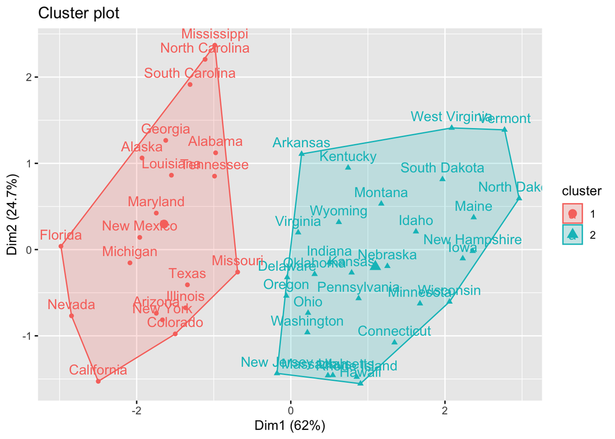

```r
#If there are more than two dimensions (variables) factoextra::fviz_cluster will perform principal component analysis (PCA) and plot the data points according to the first two principal components that explain the majority of the variance.

#visualise
arrestsPlot <- factoextra::fviz_cluster(k2, data = df)
arrestsPlot
```

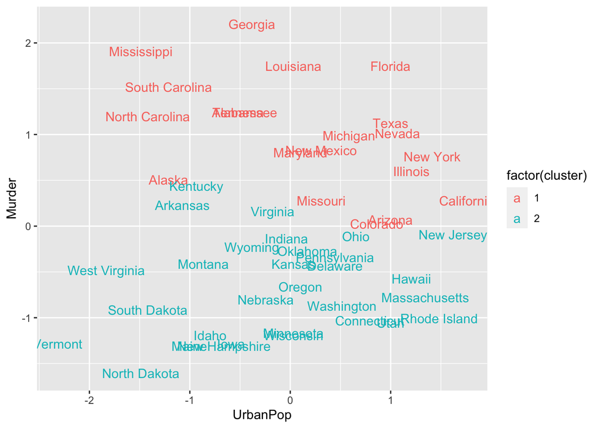

```r
#Or you could use standard pairwise scatter plots
df %>%
  dplyr::as_tibble() %>%
  dplyr::mutate(cluster = k2$cluster,
         state = row.names(USArrests)) %>%
  ggplot2::ggplot(aes(UrbanPop, Murder, color = factor(cluster), label = state)) +
  geom_text()
```

> **Useful tip:**

> If there are more than two dimensions (variables) factoextra::fviz_cluster will perform principal component analysis (PCA) and plot the data points (and the clusters) according to the first two principal components that explain the majority of the variance.

## 2 - Customer Data

Now that we’ve covered the basics of the k-mean algorithm using the open R Dataset, lets explore some real-world data!

The data set refers to clients of a wholesale distributor. It includes the annual spending in monetary units (m.u.) on diverse product categories. It includes the annual spending on a range of product categories. Let’s see if we can use k-means clustering to segment/group these customers based on their spending habits.

> janitor::clean_names() - “Resulting names are unique and consist only of the _ character, numbers, and letters”

```r
# read in data
customer <- read.csv("Wholesale customers data.csv") %>% janitor::clean_names()
```

Lets briefly explore the datatset

```r
head(customer)
```

```
##   channel region fresh milk grocery frozen detergents_paper delicassen
## 1       2      3 12669 9656    7561    214             2674       1338
## 2       2      3  7057 9810    9568   1762             3293       1776
## 3       2      3  6353 8808    7684   2405             3516       7844
## 4       1      3 13265 1196    4221   6404              507       1788
## 5       2      3 22615 5410    7198   3915             1777       5185
## 6       2      3  9413 8259    5126    666             1795       1451
```

### Data Pre-Processing

*Information about the variables*

Nominal:

- Channel: HORECA i.e. hotel/restaurant/cafe (1) or Retail Channel (2)
- Region: Linson (1), Oporto (2) or Other (3)

Continuous - the remaining variables are continuous and represent the annual spending (in monitary units) of each diverse product categories

////

Let’s have a closer look at our variables to see if we need to perform any pre-processing. It’s clear that the variables ‘Channel’ and ‘Region’ have been label encoded (each value has been converted into a number), therefore the variance for these variables will be extremely low compared to the product variables.

> XX so can we use nominal variables in k-means in this way??

### Descriptive Analysis

```r
#Use summary() function to run descriptive analysis
summary(customer)
```

```
##     channel          region          fresh             milk
##  Min.   :1.000   Min.   :1.000   Min.   :     3   Min.   :   55
##  1st Qu.:1.000   1st Qu.:2.000   1st Qu.:  3128   1st Qu.: 1533
##  Median :1.000   Median :3.000   Median :  8504   Median : 3627
##  Mean   :1.323   Mean   :2.543   Mean   : 12000   Mean   : 5796
##  3rd Qu.:2.000   3rd Qu.:3.000   3rd Qu.: 16934   3rd Qu.: 7190
##  Max.   :2.000   Max.   :3.000   Max.   :112151   Max.   :73498
##     grocery          frozen        detergents_paper    delicassen
##  Min.   :    3   Min.   :   25.0   Min.   :    3.0   Min.   :    3.0
##  1st Qu.: 2153   1st Qu.:  742.2   1st Qu.:  256.8   1st Qu.:  408.2
##  Median : 4756   Median : 1526.0   Median :  816.5   Median :  965.5
##  Mean   : 7951   Mean   : 3071.9   Mean   : 2881.5   Mean   : 1524.9
##  3rd Qu.:10656   3rd Qu.: 3554.2   3rd Qu.: 3922.0   3rd Qu.: 1820.2
##  Max.   :92780   Max.   :60869.0   Max.   :40827.0   Max.   :47943.0
```

```r
#Use ftable() function on categorical variables
table(customer$channel)
```

```
##
##   1   2
## 298 142
```

```r
table(customer$region)
```

```
##
##   1   2   3
##  77  47 316
```

When it comes to performing clustering on a given datset, you must think carefully about feature variables.

This is important for k-means clustering as it uses a *distanced-based* algorithm.

Because k-means uses the Euclidean distance to calculate the distance between data points and the centroids, we need to ensure that the distance measure accords equal weight to each variable. We don’t want to put more weight on variables that might have higher variance.

To standardise a dataset we can use `scale` (which was used in the arrests example above as well)

### Standarise the Data

> XX what is effect on standardisation of forcing it to use the channel & region variables (which only have 2 or 3 values)?

```r
customer <- scale(customer) # centres & standardises data
head(customer)
```

```
##         channel    region       fresh        milk     grocery     frozen
## [1,]  1.4470045 0.5899967  0.05287300  0.52297247 -0.04106815 -0.5886970
## [2,]  1.4470045 0.5899967 -0.39085706  0.54383861  0.17012470 -0.2698290
## [3,]  1.4470045 0.5899967 -0.44652098  0.40807319 -0.02812509 -0.1373793
## [4,] -0.6895122 0.5899967  0.09999758 -0.62331041 -0.39253008  0.6863630
## [5,]  1.4470045 0.5899967  0.83928412 -0.05233688 -0.07926595  0.1736612
## [6,]  1.4470045 0.5899967 -0.20457266  0.33368675 -0.29729863 -0.4955909
##      detergents_paper  delicassen
## [1,]      -0.04351919 -0.06626363
## [2,]       0.08630859  0.08904969
## [3,]       0.13308016  2.24074190
## [4,]      -0.49802132  0.09330484
## [5,]      -0.23165413  1.29786952
## [6,]      -0.22787885 -0.02619421
```

### Fitting k-means clustering model

We can then compute k-means in R on our scaled data using the stats::kmeans function. Here will start by grouping the data into -> three <- clusters (centers = 3). The kmeans function also has an nstart option that attempts multiple initial configurations and reports on the best one. For example, adding nstart = 20 will generate 20 initial configurations. This approach is often recommended.

> XX why is nstart = 20 used here but 25 used in the arrests example?

```r
set.seed(240) # Setting seed
kmeans.re <- stats::kmeans(customer, centers = 3, nstart = 20)
kmeans.re
```

```
## K-means clustering with 3 clusters of sizes 130, 14, 296
##
## Cluster means:
##      channel      region       fresh       milk    grocery      frozen
## 1  1.4470045  0.10318733 -0.30317725  0.4000134  0.6265509 -0.33582096
## 2  0.9891795  0.03648167  1.12803510  3.8008247  3.3674061  1.57198976
## 3 -0.6822942 -0.04704424  0.07979916 -0.3554503 -0.4344436  0.07313807
##   detergents_paper  delicassen
## 1        0.6522122  0.00359463
## 2        3.2840033  2.19608806
## 3       -0.4417690 -0.10544775
##
## Clustering vector:
##   [1] 1 1 1 3 1 1 1 1 3 1 1 1 1 1 1 3 1 3 1 3 1 3 3 2 1 1 3 3 1 3 3 3 3 3 3 1 3
##  [38] 1 1 3 3 3 1 1 1 1 1 2 1 1 3 3 1 1 3 3 2 1 3 3 1 2 1 1 3 2 3 1 3 3 3 3 3 1
##  [75] 1 3 3 1 3 3 3 1 1 3 1 2 2 3 3 3 3 3 2 3 1 3 1 3 3 3 1 1 1 3 3 3 1 1 1 1 3
## [112] 1 3 3 3 3 3 3 3 3 3 3 3 1 3 3 3 1 3 3 3 3 3 3 3 3 3 3 3 3 3 3 3 3 3 1 3 3
## [149] 3 3 3 3 3 3 3 1 1 3 1 1 1 3 3 1 1 1 1 3 3 3 1 1 3 1 3 1 3 3 3 3 3 2 3 2 3
## [186] 3 3 3 1 1 3 3 3 1 3 3 3 1 3 3 1 1 3 3 3 1 3 1 3 1 3 2 3 3 1 3 1 3 1 3 3 3
## [223] 3 1 3 3 1 3 3 3 1 3 3 3 3 3 3 3 3 3 3 3 3 3 3 1 3 3 3 3 3 2 3 3 3 3 3 3 3
## [260] 3 3 3 3 3 1 3 1 3 1 3 3 3 3 3 3 3 3 3 3 1 3 1 3 3 3 3 3 3 3 3 3 3 3 1 3 1
## [297] 3 1 1 3 1 1 1 1 1 1 1 3 3 1 3 3 1 3 3 1 3 3 3 1 3 3 3 3 3 2 3 3 3 3 3 1 3
## [334] 2 3 1 3 3 3 3 1 1 3 1 3 3 1 1 3 1 3 1 3 1 3 3 3 1 3 3 3 3 3 3 3 1 3 3 3 3
## [371] 1 3 3 1 3 3 1 3 3 1 3 3 3 3 3 3 3 3 3 3 3 3 3 3 3 3 1 3 3 3 3 3 3 3 3 3 3
## [408] 1 1 3 3 3 3 3 3 1 1 3 1 3 3 1 3 1 1 3 3 3 3 3 3 3 3 3 3 3 3 1 3 3
##
## Within cluster sum of squares by cluster:
## [1]  391.6661  730.8996 1020.2318
##  (between_SS / total_SS =  39.0 %)
##
## Available components:
##
## [1] "cluster"      "centers"      "totss"        "withinss"     "tot.withinss"
## [6] "betweenss"    "size"         "iter"         "ifault"
```

```r
#cluster identification?
kmeans.re$cluster
```

```
##   [1] 1 1 1 3 1 1 1 1 3 1 1 1 1 1 1 3 1 3 1 3 1 3 3 2 1 1 3 3 1 3 3 3 3 3 3 1 3
##  [38] 1 1 3 3 3 1 1 1 1 1 2 1 1 3 3 1 1 3 3 2 1 3 3 1 2 1 1 3 2 3 1 3 3 3 3 3 1
##  [75] 1 3 3 1 3 3 3 1 1 3 1 2 2 3 3 3 3 3 2 3 1 3 1 3 3 3 1 1 1 3 3 3 1 1 1 1 3
## [112] 1 3 3 3 3 3 3 3 3 3 3 3 1 3 3 3 1 3 3 3 3 3 3 3 3 3 3 3 3 3 3 3 3 3 1 3 3
## [149] 3 3 3 3 3 3 3 1 1 3 1 1 1 3 3 1 1 1 1 3 3 3 1 1 3 1 3 1 3 3 3 3 3 2 3 2 3
## [186] 3 3 3 1 1 3 3 3 1 3 3 3 1 3 3 1 1 3 3 3 1 3 1 3 1 3 2 3 3 1 3 1 3 1 3 3 3
## [223] 3 1 3 3 1 3 3 3 1 3 3 3 3 3 3 3 3 3 3 3 3 3 3 1 3 3 3 3 3 2 3 3 3 3 3 3 3
## [260] 3 3 3 3 3 1 3 1 3 1 3 3 3 3 3 3 3 3 3 3 1 3 1 3 3 3 3 3 3 3 3 3 3 3 1 3 1
## [297] 3 1 1 3 1 1 1 1 1 1 1 3 3 1 3 3 1 3 3 1 3 3 3 1 3 3 3 3 3 2 3 3 3 3 3 1 3
## [334] 2 3 1 3 3 3 3 1 1 3 1 3 3 1 1 3 1 3 1 3 1 3 3 3 1 3 3 3 3 3 3 3 1 3 3 3 3
## [371] 1 3 3 1 3 3 1 3 3 1 3 3 3 3 3 3 3 3 3 3 3 3 3 3 3 3 1 3 3 3 3 3 3 3 3 3 3
## [408] 1 1 3 3 3 3 3 3 1 1 3 1 3 3 1 3 1 1 3 3 3 3 3 3 3 3 3 3 3 3 1 3 3
```

```r
# Confusion Matrix
#cm <- table(customer$region, kmeans.re$cluster)
#cm
```

If we print the results we’ll see our groupings results in 3 clusters sizes of 130, 14, 296. We also get the means for the 3 groups across the variables, and the cluster assignment for each observation

### Visualusisation

Draw a pretty plot

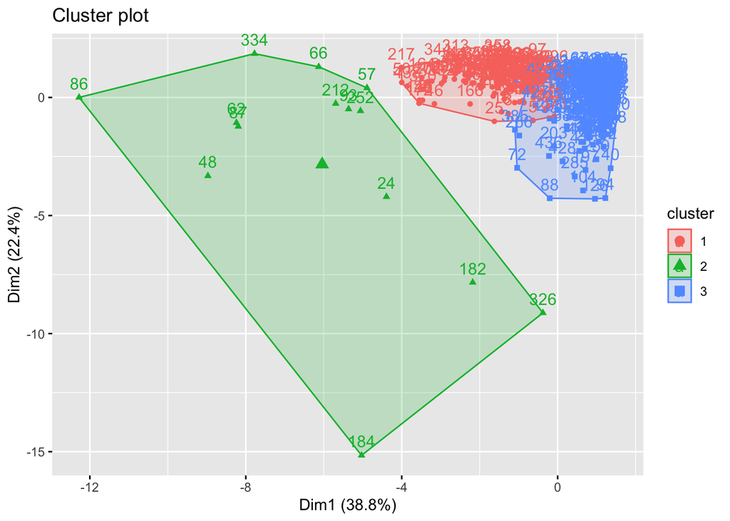

```r
factoextra::fviz_cluster(kmeans.re, data = customer)
```

> XX do we really think there ar three clusters?

### Evaluation: the elbow method

As we can see the lowest SSE produced from the algorithm runs, is quite high.

> XX which result is this? And what does ‘quite high’ mean? Relative to what?

> XX aforementioned where?

```r
#Elbow Method for finding the optimal number of clusters

#Step by Step
set.seed(123)

# Compute and plot wss for k = 2 to k = 15.
k.max <- 15

wss <- sapply(1:k.max,
              function(k){kmeans(customer, k, nstart=50,
                                 iter.max = 15 )$tot.withinss}) #extrasts tot.withinss for each loop
wss
```

```
##  [1] 3512.0000 2593.4767 2142.7975 1833.5384 1537.2253 1310.9706 1186.7129
##  [8] 1065.2028  975.0801  894.7061  843.0300  779.5657  748.2787  707.8869
## [15]  674.0171
```

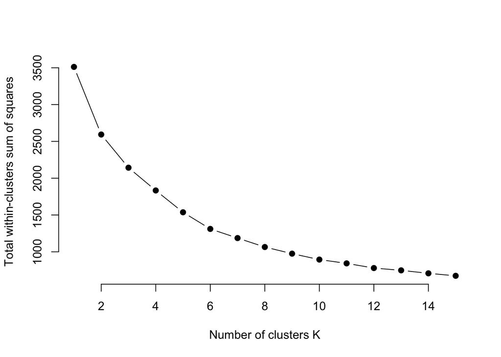

```r
plot(1:k.max, wss,
     type="b", pch = 19, frame = FALSE,
     xlab="Number of clusters K",
     ylab="Total within-clusters sum of squares")
```

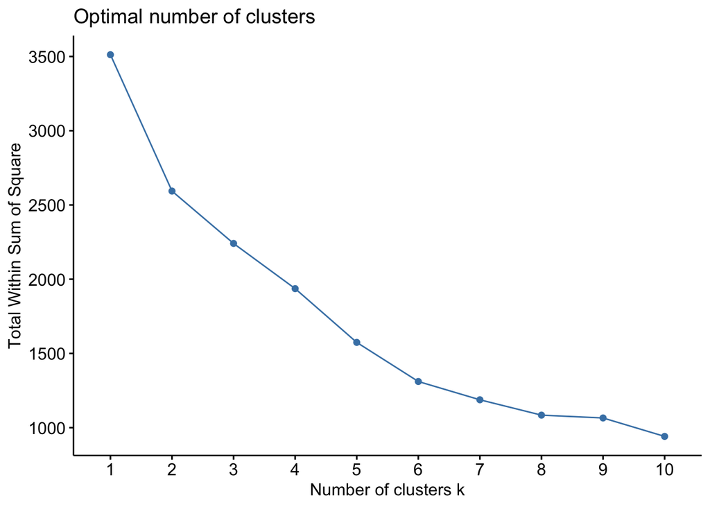

```r
#Using fviz_nbclust
set.seed(123)

factoextra::fviz_nbclust(customer, kmeans, method ="wss")
```

> XX So what does that tell us and what should we do next? Should we go with 6 as it’s a point of inflection?

### Retry with k = 6

```r
set.seed(240) # Setting seed
kmeansFinal.re <- stats::kmeans(customer, centers = 6, nstart = 25)
kmeansFinal.re
```

```
## K-means clustering with 6 clusters of sizes 174, 1, 44, 86, 125, 10
##
## Cluster means:
##      channel      region      fresh       milk    grocery       frozen
## 1 -0.6895122  0.58999669 -0.2230591 -0.3779619 -0.4747568 -0.149815514
## 2 -0.6895122  0.58999669  1.9645810  5.1696185  1.2857533  6.892753825
## 3 -0.5438406  0.29646600  1.9471842 -0.1279181 -0.2465141  1.402837578
## 4 -0.5901393 -1.58759146 -0.1172365 -0.3505932 -0.4022833  0.013336139
## 5  1.4470045  0.16637320 -0.3350464  0.4576056  0.6724594 -0.349287316
## 6  1.4470045 -0.05577083  0.3134735  3.9174467  4.2707490 -0.003570131
##   detergents_paper  delicassen
## 1       -0.4422636 -0.18614581
## 2       -0.5542311 16.45971129
## 3       -0.4171292  0.42882577
## 4       -0.4222669 -0.16183154
## 5        0.6883807  0.04760727
## 6        4.6129149  0.50279301
##
## Clustering vector:
##   [1] 5 5 5 1 5 5 5 5 1 5 5 5 5 5 5 1 5 1 5 1 5 1 3 5 5 5 1 1 5 3 1 1 1 3 1 5 3
##  [38] 5 5 3 3 1 5 5 5 5 5 6 5 5 1 1 3 5 1 1 6 5 1 1 5 6 5 5 1 6 1 5 1 1 3 3 1 5
##  [75] 5 1 1 5 1 1 1 5 5 1 5 6 6 3 1 1 1 1 6 3 5 1 5 1 1 1 5 5 5 3 1 1 5 5 5 5 1
## [112] 5 3 1 1 1 1 1 1 1 1 1 1 5 3 3 1 5 1 3 1 1 1 1 1 1 1 1 1 1 1 1 3 1 1 5 1 1
## [149] 1 1 1 1 1 1 1 5 5 1 5 5 5 1 1 5 5 5 5 1 1 1 5 5 1 5 1 5 3 1 1 1 1 3 1 2 1
## [186] 1 1 1 5 5 1 1 1 5 1 1 3 5 4 4 5 5 4 4 4 5 4 4 4 5 4 6 4 4 5 4 5 4 5 4 4 4
## [223] 4 4 4 4 4 4 4 4 4 4 4 4 4 4 4 4 4 3 4 4 4 4 4 5 4 4 4 4 4 6 4 4 4 4 4 4 3
## [260] 3 4 4 4 4 5 4 5 4 5 4 4 4 4 3 1 1 3 3 1 5 1 5 3 3 3 3 1 1 1 3 1 1 1 5 4 5
## [297] 4 5 5 4 5 5 5 5 5 5 5 4 4 5 4 4 5 4 4 5 4 4 4 5 4 4 4 4 4 3 4 4 4 4 4 5 4
## [334] 6 3 5 4 4 4 4 5 5 1 5 1 1 5 5 1 5 1 5 1 5 1 1 1 5 1 1 1 1 1 1 1 5 1 1 1 1
## [371] 3 1 1 5 1 1 5 3 1 5 1 1 3 1 1 1 1 1 1 1 1 1 1 3 1 1 5 1 1 1 1 3 1 1 1 1 3
## [408] 5 5 1 1 1 1 3 1 5 5 1 5 1 1 5 1 5 5 3 1 3 1 1 1 1 1 1 1 3 3 5 1 1
##
## Within cluster sum of squares by cluster:
## [1] 177.5656   0.0000 418.3745 165.2427 389.4974 160.2905
##  (between_SS / total_SS =  62.7 %)
##
## Available components:
##
## [1] "cluster"      "centers"      "totss"        "withinss"     "tot.withinss"
## [6] "betweenss"    "size"         "iter"         "ifault"
```

```r
#cluster identification?
kmeansFinal.re$cluster
```

```
##   [1] 5 5 5 1 5 5 5 5 1 5 5 5 5 5 5 1 5 1 5 1 5 1 3 5 5 5 1 1 5 3 1 1 1 3 1 5 3
##  [38] 5 5 3 3 1 5 5 5 5 5 6 5 5 1 1 3 5 1 1 6 5 1 1 5 6 5 5 1 6 1 5 1 1 3 3 1 5
##  [75] 5 1 1 5 1 1 1 5 5 1 5 6 6 3 1 1 1 1 6 3 5 1 5 1 1 1 5 5 5 3 1 1 5 5 5 5 1
## [112] 5 3 1 1 1 1 1 1 1 1 1 1 5 3 3 1 5 1 3 1 1 1 1 1 1 1 1 1 1 1 1 3 1 1 5 1 1
## [149] 1 1 1 1 1 1 1 5 5 1 5 5 5 1 1 5 5 5 5 1 1 1 5 5 1 5 1 5 3 1 1 1 1 3 1 2 1
## [186] 1 1 1 5 5 1 1 1 5 1 1 3 5 4 4 5 5 4 4 4 5 4 4 4 5 4 6 4 4 5 4 5 4 5 4 4 4
## [223] 4 4 4 4 4 4 4 4 4 4 4 4 4 4 4 4 4 3 4 4 4 4 4 5 4 4 4 4 4 6 4 4 4 4 4 4 3
## [260] 3 4 4 4 4 5 4 5 4 5 4 4 4 4 3 1 1 3 3 1 5 1 5 3 3 3 3 1 1 1 3 1 1 1 5 4 5
## [297] 4 5 5 4 5 5 5 5 5 5 5 4 4 5 4 4 5 4 4 5 4 4 4 5 4 4 4 4 4 3 4 4 4 4 4 5 4
## [334] 6 3 5 4 4 4 4 5 5 1 5 1 1 5 5 1 5 1 5 1 5 1 1 1 5 1 1 1 1 1 1 1 5 1 1 1 1
## [371] 3 1 1 5 1 1 5 3 1 5 1 1 3 1 1 1 1 1 1 1 1 1 1 3 1 1 5 1 1 1 1 3 1 1 1 1 3
## [408] 5 5 1 1 1 1 3 1 5 5 1 5 1 1 5 1 5 5 3 1 3 1 1 1 1 1 1 1 3 3 5 1 1
```

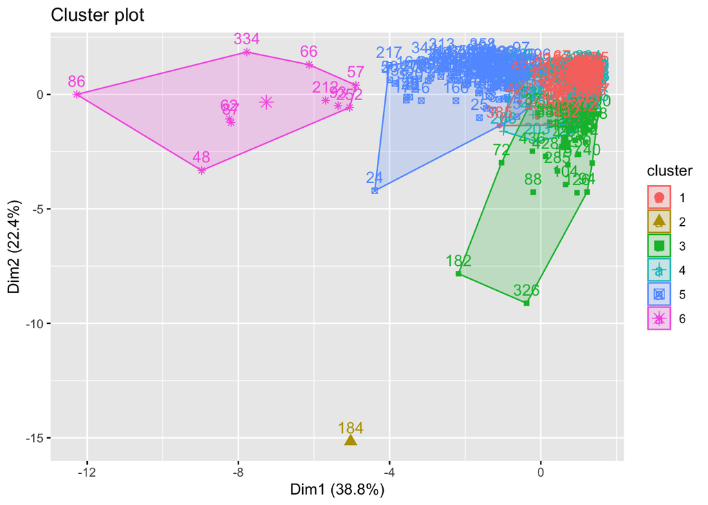

```r
# Confusion Matrix
#cm <- table(customer$region, kmeansFinal.re$cluster)
#cm

factoextra::fviz_cluster(kmeansFinal.re, data = customer)
```

> Hmmmmm

### Extra Activities: PCA on the customer dataset

If there are more than two dimensions (variables) factoextra::fviz_cluster will perform principal component analysis (PCA) and plot the data points according to the first two principal components that explain the majority of the variance.

> XX looks like this code just does explicit PCA using `prcomp`

> XX why are we reversing signs etc?

```r
#calculate principal components
results <- stats::prcomp(customer, scale = TRUE)

#reverse the signs
results$rotation <- -1*results$rotation

#display principal components
results$rotation
```

```
##                          PC1         PC2           PC3         PC4         PC5
## channel           0.42829156 -0.20469886 -0.0829798863  0.02964416 -0.03620585
## region            0.02472603  0.04312964 -0.9825008891  0.07784462  0.13250892
## fresh            -0.02531946  0.51344468 -0.0889509074 -0.79847592 -0.25811686
## milk              0.47440995  0.20554061  0.0257510842  0.05402202 -0.07208576
## grocery           0.53632914 -0.00871762  0.0453143572 -0.12158624  0.11172990
## frozen           -0.02997456  0.59274525  0.1221565222  0.16131688  0.75421244
## detergents_paper  0.52390630 -0.12108309  0.0474814388 -0.15101211  0.17650264
## delicassen        0.16499653  0.53318082 -0.0009301994  0.53755767 -0.54482721
##                          PC6          PC7          PC8
## channel           0.86350670 -0.139899044 -0.019335373
## region           -0.08976479  0.023279938  0.001545045
## fresh             0.14747474  0.027173693  0.033851114
## milk             -0.31593256 -0.789020414  0.039291347
## grocery          -0.21369889  0.353064294 -0.715984124
## frozen            0.19435993  0.005336793  0.012983225
## detergents_paper -0.19575356  0.371374310  0.691672189
## delicassen        0.05453289  0.306582655  0.075642587
```

```r
#reverse the signs of the scores
results$x <- -1*results$x

#display the first six scores
head(results$x)
```

```
##             PC1        PC2        PC3         PC4        PC5        PC6
## [1,]  0.8429794 -0.5147648 -0.7667594 -0.04416453 -0.4457267  0.9383731
## [2,]  1.0614682 -0.4840503 -0.6722101  0.40091542 -0.1303098  0.8662408
## [3,]  1.2676975  0.6812791 -0.6633395  1.63309380 -1.1924556  1.0772155
## [4,] -1.0555808  0.6101270 -0.5050795  0.19578209  0.4573340 -0.1168258
## [5,]  0.6333096  0.9730912 -0.7703319  0.18616222 -0.8129520  1.5036608
## [6,]  0.5295082 -0.5847458 -0.7577620  0.24672790 -0.3784085  1.0713344
##             PC7         PC8
## [1,] -0.6540173 -0.01808111
## [2,] -0.5104414 -0.07780623
## [3,]  0.2029209  0.25374856
## [4,]  0.3134471 -0.05431530
## [5,]  0.1602166 -0.00375915
## [6,] -0.6578136  0.02594706
```

```r
# print results
print(results)
```

```
## Standard deviations (1, .., p=8):
## [1] 1.7606845 1.3378965 1.0058697 0.8592976 0.7460780 0.6777229 0.5302132
## [8] 0.2505796
##
## Rotation (n x k) = (8 x 8):
##                          PC1         PC2           PC3         PC4         PC5
## channel           0.42829156 -0.20469886 -0.0829798863  0.02964416 -0.03620585
## region            0.02472603  0.04312964 -0.9825008891  0.07784462  0.13250892
## fresh            -0.02531946  0.51344468 -0.0889509074 -0.79847592 -0.25811686
## milk              0.47440995  0.20554061  0.0257510842  0.05402202 -0.07208576
## grocery           0.53632914 -0.00871762  0.0453143572 -0.12158624  0.11172990
## frozen           -0.02997456  0.59274525  0.1221565222  0.16131688  0.75421244
## detergents_paper  0.52390630 -0.12108309  0.0474814388 -0.15101211  0.17650264
## delicassen        0.16499653  0.53318082 -0.0009301994  0.53755767 -0.54482721
##                          PC6          PC7          PC8
## channel           0.86350670 -0.139899044 -0.019335373
## region           -0.08976479  0.023279938  0.001545045
## fresh             0.14747474  0.027173693  0.033851114
## milk             -0.31593256 -0.789020414  0.039291347
## grocery          -0.21369889  0.353064294 -0.715984124
## frozen            0.19435993  0.005336793  0.012983225
## detergents_paper -0.19575356  0.371374310  0.691672189
## delicassen        0.05453289  0.306582655  0.075642587
```

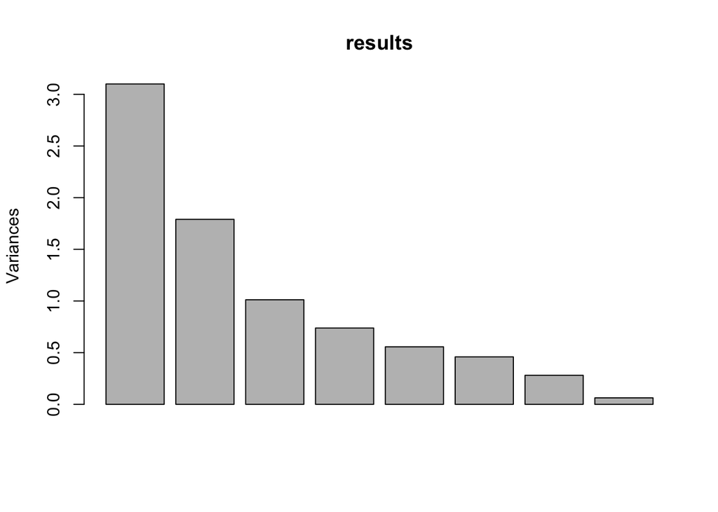

```r
#scree plot results
plot(results)
```

> XX what was the point of all that?

### Visualise

> X - seems to (atttempt to) plot the dimensions with axes

“A biplot is plot which aims to represent both the observations and variables of a matrix of multivariate data on the same plot.”

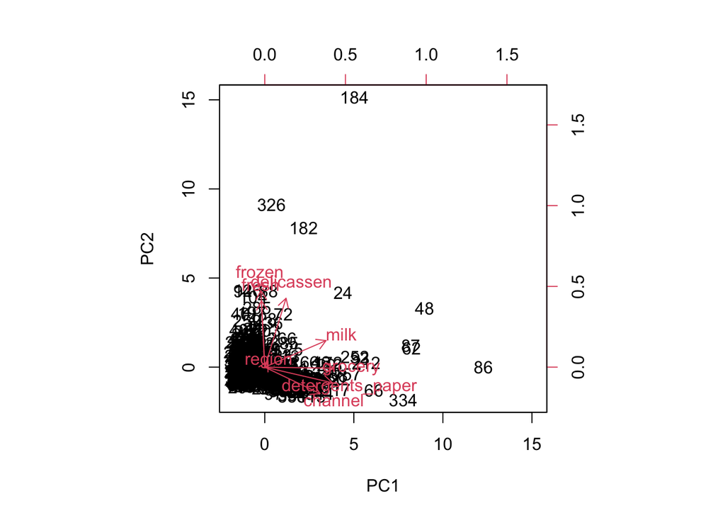

```r
stats::biplot(results, scale = 0)
```

> right

## Extra Activities: Looking at just frozen vs grocery

```r
# #### Model Evaluation and visualization
#
# plot(customer[c("grocery", "frozen")])
# plot(customer[c("grocery", "frozen")],
#      col = kmeans.re$cluster)
# plot(customer[c("grocery", "frozen")],
#      col = kmeans.re$cluster,
#      main = "K-means with 3 clusters")
#
# ## Plotiing cluster centers
# kmeans.re$centers
# kmeans.re$centers[, c("grocery", "frozen")]
#
# # cex is font size, pch is symbol
# points(kmeans.re$centers[, c("grocery", "frozen")],
#        col = 1:3, pch = 8, cex = 3)
#
# ## Visualizing clusters
# y_kmeans <- kmeans.re$cluster
# clusplot(customer[, c("grocery", "frozen")],
#          y_kmeans,
#          lines = 0,
#          shade = TRUE,
#          color = TRUE,
#          labels = 2,
#          plotchar = FALSE,
#          span = TRUE,
#          main = paste("Cluster"),
#          xlab = 'grocery',
#          ylab = 'frozen')
```

# The end

> How is this ‘machine learning’? Just feels like fairly standard cluster analysis.